# ML Assignment 2 (Road Sign Classification)

```python
import pandas as pd
import cv2
import os
import matplotlib.pyplot as plt
import numpy as np
import seaborn as sns
from sklearn.preprocessing import MinMaxScaler, PowerTransformer
from sklearn.model_selection import train_test_split, cross_validate, cross_val_score, RepeatedStratifiedKFold
from sklearn.ensemble import RandomForestClassifier
from sklearn.metrics import classification_report, accuracy_score, plot_confusion_matrix, make_scorer, f1_score, confusion_matrix
from sklearn.datasets import make_classification
import cv2 as cv
from matplotlib import pyplot as plt
from skimage.io import imread, imshow
from skimage.feature import hog
from skimage import data, exposure
import tensorflow as tf
from tensorflow.keras.preprocessing.image import ImageDataGenerator
from tensorflow import keras
from tensorflow.keras.preprocessing import image

import numpy as np
from sklearn.model_selection import train_test_split
import pandas as pd

from tensorflow.keras.preprocessing.image import ImageDataGenerator
```

## Firstly, we realised there was no CSV file given to help load the images therefore we decided to create our own one to load the road signs. Based on week 9 tutorial there is a csv to that has directory for each image

## This is so that we can train our machine to read all the road sign images

```python
def load_images_from_folder(folder):
    images = []
    for filename in os.listdir(folder):
        img = cv2.imread(os.path.join(folder,filename))
        if img is not None:
            images.append(img)
    return images
```

## Glob module is used to retrieve files/pathnames matching a specified pattern. This is to create two csv classes, one for sign shape and the other for sign types.

```python
import glob
images = []
classes = []
classes.extend([file.split("\\")[1] for file in glob.glob('trafficsigns_dataset/*/*/*.png')])
images.extend([(file) for file in glob.glob('trafficsigns_dataset/*/*/*.png')])
```

## To print it out to csv

```python
## to print out csv
dict = {'image_path': images, 'class': classes}
predict_df = pd.DataFrame(dict)
predict_df.to_csv('signboardimage1.csv', index=False)
```

## Now, we need to load the data from csv file:

## This csv contains class to classify the sign board shapes, Therefore we will start to develop a model that can classify shapes.

```python
data = pd.read_csv('./signboardimage1.csv')
data.head(10)
```

|  | image_path | class |
| --- | --- | --- |
| 0 | trafficsigns_dataset\diamond\rightofway\00032_... | diamond |
| 1 | trafficsigns_dataset\diamond\rightofway\00032_... | diamond |
| 2 | trafficsigns_dataset\diamond\rightofway\00032_... | diamond |
| 3 | trafficsigns_dataset\diamond\rightofway\00037_... | diamond |
| 4 | trafficsigns_dataset\diamond\rightofway\00037_... | diamond |
| 5 | trafficsigns_dataset\diamond\rightofway\00037_... | diamond |
| 6 | trafficsigns_dataset\diamond\rightofway\00039_... | diamond |
| 7 | trafficsigns_dataset\diamond\rightofway\00039_... | diamond |
| 8 | trafficsigns_dataset\diamond\rightofway\00039_... | diamond |
| 9 | trafficsigns_dataset\diamond\rightofway\00042_... | diamond |

### Just checking for any empty data

```python
print(data.isna().sum())
```

```
image_path    0
class         0
dtype: int64
```

### If an empty or null data is present, we delete by using the following code below

```python
for col in data.columns:
    data[col].replace('', np.nan, inplace=True)
    data.dropna(subset = [col] , inplace=True)
```

```
(28, 28)
```

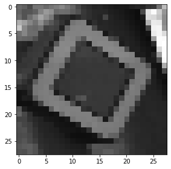

```python
img = imread(data['image_path'][0])
imshow(img)
img.shape
```

## Now we will start developing our model

## 1. Our goals for this project:

### - Our goal is to develop a Convolutional Neural Network to be able to classify sign board shape and sign board type

### - Develop a model that have at least 70% accuracy.

## 2. The start of our Baseline Model:

### Firstly, we would need to split the data we have into train, test and validation sets.

```python
train_data, test_data = train_test_split(data, test_size=0.2, random_state=42)
train_data, val_data = train_test_split(train_data, test_size=0.25, random_state=42)

print("Train data : {}, Val Data: {}, Test Data: {}".format(train_data.shape[0], val_data.shape[0], test_data.shape[0]))
```

```
Train data : 2219, Val Data: 740, Test Data: 740
```

```python
train_data['class'] = train_data['class'].astype('str')
val_data['class'] = val_data['class'].astype('str')
```

### Create a data generator for each split of sets.

```python
train_datagen = ImageDataGenerator(rescale=1./255, data_format='channels_last')
val_datagen = ImageDataGenerator(rescale=1./255, data_format='channels_last')

batch_size = 32

train_generator = train_datagen.flow_from_dataframe(
        dataframe=train_data,
        directory='./',
        x_col="image_path",
        y_col="class",
        target_size=(32, 32),
        batch_size=batch_size,
        class_mode='categorical')

validation_generator = val_datagen.flow_from_dataframe(
        dataframe=val_data,
        directory='./',
        x_col="image_path",
        y_col="class",
        target_size=(32, 32),
        batch_size=batch_size,
        class_mode='categorical')
```

```
Found 2219 validated image filenames belonging to 5 classes.
Found 740 validated image filenames belonging to 5 classes.
```

```python
test_data['class'] = test_data['class'].astype('str')

test_datagen = ImageDataGenerator(rescale=1./255, data_format='channels_last')

batch_size = 1

test_generator = test_datagen.flow_from_dataframe(
        dataframe=test_data,
        directory='./',
        x_col="image_path",
        y_col="class",
        target_size=(32, 32),
        batch_size=batch_size,
        class_mode='categorical')
```

```
Found 740 validated image filenames belonging to 5 classes.
```

### To check the if the classes for each sets are present and labelled

```python
train_generator.class_indices
```

```
{'diamond': 0, 'hex': 1, 'round': 2, 'square': 3, 'triangle': 4}
```

```python
validation_generator.class_indices
```

```
{'diamond': 0, 'hex': 1, 'round': 2, 'square': 3, 'triangle': 4}
```

```python
INPUT_DIM = (32,32,3) # (x-axis size of image, y axis size of image, rgb 3 colours)
HIDDEN_LAYER_DIM = 256
OUTPUT_CLASSES = 5
```

### Now we will set up the layers of our neural network using sequential api that was given to us for week 9 lab.

```python
modelA = tf.keras.Sequential([
    tf.keras.layers.Flatten(input_shape=INPUT_DIM),
    tf.keras.layers.Dense(HIDDEN_LAYER_DIM, activation='sigmoid'),
    tf.keras.layers.Dense(OUTPUT_CLASSES)
])
```

[output not shown]

```python
modelA.summary()
```

```
Model: "sequential"
_________________________________________________________________
Layer (type)                 Output Shape              Param #
=================================================================
flatten (Flatten)            (None, 3072)              0
_________________________________________________________________
dense (Dense)                (None, 256)               786688
_________________________________________________________________
dense_1 (Dense)              (None, 5)                 1285
=================================================================
Total params: 787,973
Trainable params: 787,973
Non-trainable params: 0
_________________________________________________________________
```

```python
### To show the model as a figure
```

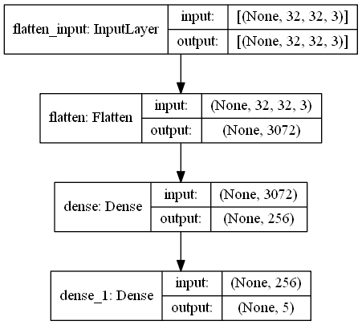

```python
tf.keras.utils.plot_model(modelA, show_shapes=True)
```

### We compile the model before we are ready to train it. Compilling gives us loss function, optimizer and metrics

```python
modelA.compile(optimizer='SGD',
              loss=tf.keras.losses.CategoricalCrossentropy(from_logits=True),
              metrics=['categorical_accuracy'])
```

### This function is to plot the learning curve of a Neutral Network training process

```python
def plot_learning_curve(train_loss, val_loss, train_metric, val_metric, metric_name='Accuracy'):
    plt.figure(figsize=(10,5))

    plt.subplot(1,2,1)
    plt.plot(train_loss, 'r--')
    plt.plot(val_loss, 'b--')
    plt.xlabel("epochs")
    plt.ylabel("Loss")
    plt.legend(['train', 'val'], loc='upper left')

    plt.subplot(1,2,2)
    plt.plot(train_metric, 'r--')
    plt.plot(val_metric, 'b--')
    plt.xlabel("epochs")
    plt.ylabel(metric_name)
    plt.legend(['train', 'val'], loc='upper left')

    plt.show()
```

```python
history = modelA.fit_generator(train_generator, validation_data = validation_generator, epochs=50, verbose=1)
```

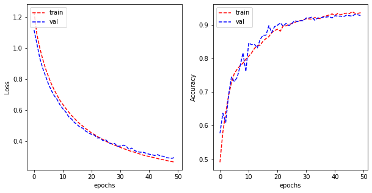

```python
plot_learning_curve(history.history['loss'], history.history['val_loss'],
                    history.history['categorical_accuracy'], history.history['val_categorical_accuracy'],
                    metric_name='Accuracy')
```

### From the learning plot above we can investigate and conclude that the train and val from loss decreases as epochs increases.

### It show below that the model has a relatively high categorical accuracy which is 89% and the loss is low.

```python
modelA.evaluate(test_generator)
```

```
[0.3479352298545072, 0.8945946]
```

### Set label names to its respective name to numbers we set

```python
label_names = {'diamond': 0, 'hex': 1, 'round': 2, 'square': 3, 'triangle': 4}
```

## Now with our trained model, we have created a model that is able to classify sign shapes as show below.

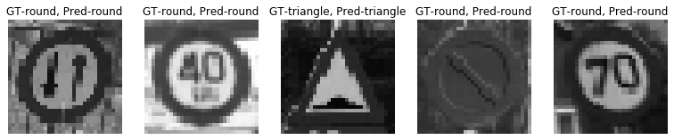

```python
d_inv = {v: k for k, v in label_names.items()}
plt.figure(figsize=(16,4))
batches = 0
for x,y in test_generator:
        batches = batches + 1
        y_hat = modelA.predict(x, verbose=0)
        x = np.squeeze(x)
        if batches < 6:
            plt.subplot(1,6,batches)
            plt.imshow(x)
            plt.title("GT-{}, Pred-{}".format(d_inv[np.argmax(y[0])], d_inv[np.argmax(y_hat[0])] ))

        else:
            break

        plt.axis('off')
```

## Tried to test indepent variable for testing my own image but couldnt figure out how to flatten one image so it can read

```python
# imgs = image.load_img('./testSign/walk.PNG', target_size =(32,32))
# plt.imshow(imgs)
# plt.show
# X = image.img_to_array(imgs)
# X = np.expand_dims(X, axis = 0)
# images = np.vstack(x)


# # images = tf.keras.Sequential([
# #     tf.keras.layers.Flatten(input_shape=INPUT_DIM)])

# val = model.predict(images)

# if val == 0:
#     print('diamond')
# else:
#     print('not diamond')
```

## Now we will make so incremental changes to our model. An explanation of early stop can be found below as initially I didn't use it but decided to for both classification of sign shape and sign type.

```python
modelB = tf.keras.Sequential([

    tf.keras.layers.Conv2D(16, (3, 3), activation='relu', padding='same', input_shape=INPUT_DIM),
    tf.keras.layers.Conv2D(16, (3, 3), activation='relu', padding='same'),
    tf.keras.layers.MaxPooling2D((2, 2)),

    tf.keras.layers.Conv2D(32, (3, 3), activation='relu', padding='same'),
    tf.keras.layers.Conv2D(32, (3, 3), activation='relu', padding='same'),
    tf.keras.layers.MaxPooling2D((2, 2)),


    tf.keras.layers.Conv2D(64, (3, 3), activation='relu', padding='same'),
    tf.keras.layers.Conv2D(64, (3, 3), activation='relu', padding='same'),
    tf.keras.layers.MaxPooling2D((2, 2)),


    tf.keras.layers.Conv2D(128, (3, 3), activation='relu', padding='same'),
    tf.keras.layers.Conv2D(128, (3, 3), activation='relu', padding='same'),
    tf.keras.layers.MaxPooling2D((2, 2)),

    tf.keras.layers.Flatten(),
    tf.keras.layers.Dense(128, activation='relu'),
    tf.keras.layers.Dense(OUTPUT_CLASSES),
])
modelB.compile(optimizer='SGD',
              loss=tf.keras.losses.CategoricalCrossentropy(from_logits=True),
              metrics=['categorical_accuracy'])
```

```python
modelB.summary()
```

```
Model: "sequential_1"
_________________________________________________________________
Layer (type)                 Output Shape              Param #
=================================================================
conv2d (Conv2D)              (None, 32, 32, 16)        448
_________________________________________________________________
conv2d_1 (Conv2D)            (None, 32, 32, 16)        2320
_________________________________________________________________
max_pooling2d (MaxPooling2D) (None, 16, 16, 16)        0
_________________________________________________________________
conv2d_2 (Conv2D)            (None, 16, 16, 32)        4640
_________________________________________________________________
conv2d_3 (Conv2D)            (None, 16, 16, 32)        9248
_________________________________________________________________
max_pooling2d_1 (MaxPooling2 (None, 8, 8, 32)          0
_________________________________________________________________
conv2d_4 (Conv2D)            (None, 8, 8, 64)          18496
_________________________________________________________________
conv2d_5 (Conv2D)            (None, 8, 8, 64)          36928
_________________________________________________________________
max_pooling2d_2 (MaxPooling2 (None, 4, 4, 64)          0
_________________________________________________________________
conv2d_6 (Conv2D)            (None, 4, 4, 128)         73856
_________________________________________________________________
conv2d_7 (Conv2D)            (None, 4, 4, 128)         147584
_________________________________________________________________
max_pooling2d_3 (MaxPooling2 (None, 2, 2, 128)         0
_________________________________________________________________
flatten_1 (Flatten)          (None, 512)               0
_________________________________________________________________
dense_2 (Dense)              (None, 128)               65664
_________________________________________________________________
dense_3 (Dense)              (None, 5)                 645
=================================================================
Total params: 359,829
Trainable params: 359,829
Non-trainable params: 0
_________________________________________________________________
```

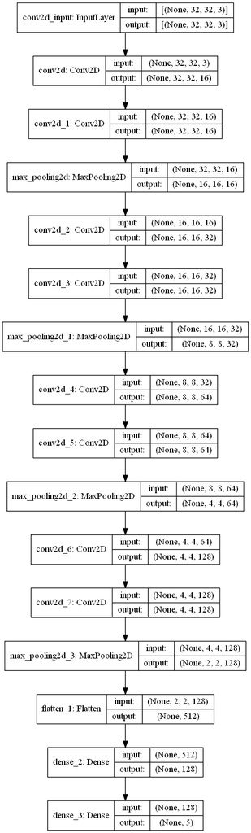

```python
tf.keras.utils.plot_model(modelB, show_shapes=True)
```

```python
modelB.compile(optimizer='SGD',
              loss=tf.keras.losses.CategoricalCrossentropy(from_logits=True),
              metrics=['categorical_accuracy'])
```

```python
def plot_learning_curve(train_loss, val_loss, train_metric, val_metric, metric_name='Accuracy'):
    plt.figure(figsize=(10,5))

    plt.subplot(1,2,1)
    plt.plot(train_loss, 'r--')
    plt.plot(val_loss, 'b--')
    plt.xlabel("epochs")
    plt.ylabel("Loss")
    plt.legend(['train', 'val'], loc='upper left')

    plt.subplot(1,2,2)
    plt.plot(train_metric, 'r--')
    plt.plot(val_metric, 'b--')
    plt.xlabel("epochs")
    plt.ylabel(metric_name)
    plt.legend(['train', 'val'], loc='upper left')

    plt.show()
```

```python
from tensorflow.keras.callbacks import EarlyStopping
es = EarlyStopping(min_delta=0.001, monitor='val_loss', mode='min', verbose=1, patience=20, restore_best_weights=True,)
```

```python
historyEarlyStop = modelB.fit_generator(train_generator, validation_data = validation_generator, epochs=50,callbacks=[es], verbose=1)
```

```
Epoch 00043: early stopping
```

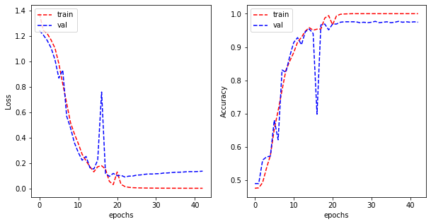

```python
plot_learning_curve(historyEarlyStop.history['loss'], historyEarlyStop.history['val_loss'],
                    historyEarlyStop.history['categorical_accuracy'], historyEarlyStop.history['val_categorical_accuracy'],
                    metric_name='Accuracy')
```

```python
modelB.evaluate(test_generator)
```

```
[0.11512069000115845, 0.96756756]
```

## It shows above that the accuracy is higher when we decided to use a classical convolutional neural network architecture

```python
label_names = {'diamond': 0, 'hex': 1, 'round': 2, 'square': 3, 'triangle': 4}
```

## Now with our trained model, we have created a model that is able to classify sign shapes as show below.

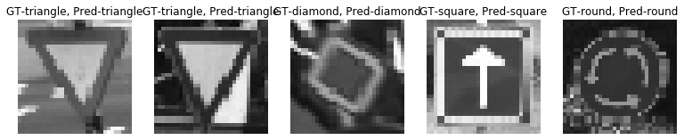

```python
d_inv = {v: k for k, v in label_names.items()}
plt.figure(figsize=(16,4))
batches = 0
for x,y in test_generator:
        batches = batches + 1
        y_hat = modelB.predict(x, verbose=0)
        x = np.squeeze(x)
        if batches < 6:
            plt.subplot(1,6,batches)
            plt.imshow(x)
            plt.title("GT-{}, Pred-{}".format(d_inv[np.argmax(y[0])], d_inv[np.argmax(y_hat[0])] ))

        else:
            break

        plt.axis('off')
```

## To choose one of the image from the dataset change target number

[figure not shown]

```python
d_inv = {v: k for k, v in label_names.items()}
plt.figure(figsize=(16,4))
target = 5000
batches = 0
for x,y in test_generator:
        batches = batches + 1
        y_hat = modelB.predict(x, verbose=0)
        x = np.squeeze(x)
        if batches == target:
            plt.subplot(1,4,1)
            plt.imshow(x)
            plt.title("GT-{}, Pred-{}".format(d_inv[np.argmax(y[0])], d_inv[np.argmax(y_hat[0])] ))
            break
        plt.axis('off')
```

# Now we will develop a model that can classify the sign board type.

```python
import cv2
import os

def load_images_from_folder(folder):
    images = []
    for filename in os.listdir(folder):
        img = cv2.imread(os.path.join(folder,filename))
        if img is not None:
            images.append(img)
    return images
```

## We change the to [2] so that we can print out a csv that get sign type instead of shape

```python
## this is to create two csv classes, one for sign shape and the other for sign types. Change the [1 or 2]

import glob
images = []
classes = []
classes.extend([file.split("\\")[2] for file in glob.glob('trafficsigns_dataset/*/*/*.png')])
images.extend([(file) for file in glob.glob('trafficsigns_dataset/*/*/*.png')])
```

```python
## CSV is print and saved into our device

dict = {'image_path': images, 'class': classes}
predict_df = pd.DataFrame(dict)
predict_df.to_csv('signboardimage2.csv', index=False)
```

```python
data2 = pd.read_csv('./signboardimage2.csv')
```

### Same thing previously, we need to split the data in to train, test and val

```python
train_data, test_data = train_test_split(data2, test_size=0.2, random_state=42)
train_data, val_data = train_test_split(train_data, test_size=0.25, random_state=42)

print("Train data : {}, Val Data: {}, Test Data: {}".format(train_data.shape[0], val_data.shape[0], test_data.shape[0]))
```

```
Train data : 2219, Val Data: 740, Test Data: 740
```

```python
train_data['class'] = train_data['class'].astype('str')
val_data['class'] = val_data['class'].astype('str')
```

```python
from tensorflow.keras.preprocessing.image import ImageDataGenerator

train_datagen = ImageDataGenerator(rescale=1./255, data_format='channels_last')
val_datagen = ImageDataGenerator(rescale=1./255, data_format='channels_last')

batch_size = 32

train_generator2 = train_datagen.flow_from_dataframe(
        dataframe=train_data,
        directory='./',
        x_col="image_path",
        y_col="class",
        target_size=(32, 32),
        batch_size=batch_size,
        class_mode='categorical')

validation_generator2 = val_datagen.flow_from_dataframe(
        dataframe=val_data,
        directory='./',
        x_col="image_path",
        y_col="class",
        target_size=(32, 32),
        batch_size=batch_size,
        class_mode='categorical')
```

```
Found 2219 validated image filenames belonging to 16 classes.
Found 740 validated image filenames belonging to 16 classes.
```

```python
train_generator2.class_indices
```

```
{'bicycle': 0,
 'continue': 1,
 'crossing': 2,
 'giveway': 3,
 'laneend': 4,
 'limitedtraffic': 5,
 'noentry': 6,
 'noparking': 7,
 'parking': 8,
 'rightofway': 9,
 'roundabout': 10,
 'speed': 11,
 'stop': 12,
 'trafficdirective': 13,
 'traveldirection': 14,
 'warning': 15}
```

```python
validation_generator2.class_indices
```

```
{'bicycle': 0,
 'continue': 1,
 'crossing': 2,
 'giveway': 3,
 'laneend': 4,
 'limitedtraffic': 5,
 'noentry': 6,
 'noparking': 7,
 'parking': 8,
 'rightofway': 9,
 'roundabout': 10,
 'speed': 11,
 'stop': 12,
 'trafficdirective': 13,
 'traveldirection': 14,
 'warning': 15}
```

```python
INPUT_DIM2 = (32,32,3) # (x-axis size of image, y axis size of image, rgb 3 colours)
HIDDEN_LAYER_DIM2 = 256
OUTPUT_CLASSES2 = 16
```

### Here is where it is slightly different from above, we decided to set different layers their the previous model as it output us very high loss and low accuracy.

```python
model2C= tf.keras.Sequential()
model2C.add(tf.keras.layers.Conv2D(filters=32,kernel_size=(3,3),
  strides=(3,3), input_shape = INPUT_DIM2, activation='relu'))
model2C.add(tf.keras.layers.Conv2D(filters=64,kernel_size=(3,3),
  activation='relu'))
model2C.add(tf.keras.layers.MaxPooling2D(pool_size = (2, 2)))
model2C.add(tf.keras.layers.Dropout(0.25))
model2C.add(tf.keras.layers.Flatten())
model2C.add(tf.keras.layers.Dense(128, activation='relu'))
model2C.add(tf.keras.layers.Dropout(0.5))
model2C.add(tf.keras.layers.Dense(16,activation = 'sigmoid'))
```

```python
model2C.summary()
```

```
Model: "sequential_2"
_________________________________________________________________
Layer (type)                 Output Shape              Param #
=================================================================
conv2d_8 (Conv2D)            (None, 10, 10, 32)        896
_________________________________________________________________
conv2d_9 (Conv2D)            (None, 8, 8, 64)          18496
_________________________________________________________________
max_pooling2d_4 (MaxPooling2 (None, 4, 4, 64)          0
_________________________________________________________________
dropout (Dropout)            (None, 4, 4, 64)          0
_________________________________________________________________
flatten_2 (Flatten)          (None, 1024)              0
_________________________________________________________________
dense_4 (Dense)              (None, 128)               131200
_________________________________________________________________
dropout_1 (Dropout)          (None, 128)               0
_________________________________________________________________
dense_5 (Dense)              (None, 16)                2064
=================================================================
Total params: 152,656
Trainable params: 152,656
Non-trainable params: 0
_________________________________________________________________
```

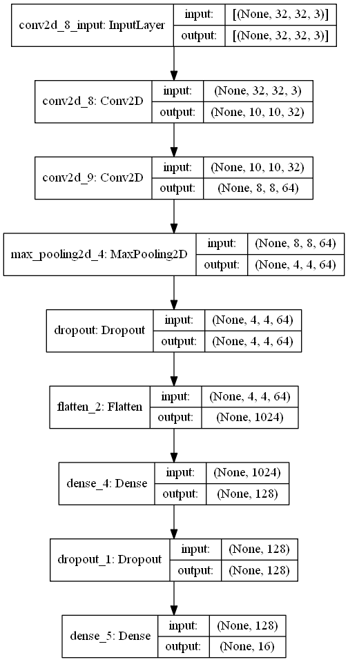

```python
tf.keras.utils.plot_model(model2C, show_shapes=True)
```

```python
model2C.compile(optimizer='SGD',
              loss=tf.keras.losses.CategoricalCrossentropy(from_logits=True),
              metrics=['categorical_accuracy'])
```

```python
train_datagen = ImageDataGenerator(rescale=1./255, data_format='channels_last')
val_datagen = ImageDataGenerator(rescale=1./255, data_format='channels_last')

batch_size = 32

train_generator2 = train_datagen.flow_from_dataframe(
        dataframe=train_data,
        directory='./',
        x_col="image_path",
        y_col="class",
        target_size=(32, 32),
        batch_size=batch_size,
        class_mode='categorical')

validation_generator2 = val_datagen.flow_from_dataframe(
        dataframe=val_data,
        directory='./',
        x_col="image_path",
        y_col="class",
        target_size=(32, 32),
        batch_size=batch_size,
        class_mode='categorical')
```

```
Found 2219 validated image filenames belonging to 16 classes.
Found 740 validated image filenames belonging to 16 classes.
```

```python
def plot_learning_curve(train_loss, val_loss, train_metric, val_metric, metric_name='Accuracy'):
    plt.figure(figsize=(10,5))

    plt.subplot(1,2,1)
    plt.plot(train_loss, 'r--')
    plt.plot(val_loss, 'b--')
    plt.xlabel("epochs")
    plt.ylabel("Loss")
    plt.legend(['train', 'val'], loc='upper left')

    plt.subplot(1,2,2)
    plt.plot(train_metric, 'r--')
    plt.plot(val_metric, 'b--')
    plt.xlabel("epochs")
    plt.ylabel(metric_name)
    plt.legend(['train', 'val'], loc='upper left')

    plt.show()
```

```python
test_data['class'] = test_data['class'].astype('str')

test_datagen = ImageDataGenerator(rescale=1./255, data_format='channels_last')

batch_size = 1

test_generator2 = test_datagen.flow_from_dataframe(
        dataframe=test_data,
        directory='./',
        x_col="image_path",
        y_col="class",
        target_size=(32, 32),
        batch_size=batch_size,
        class_mode='categorical')
```

```
Found 740 validated image filenames belonging to 16 classes.
```

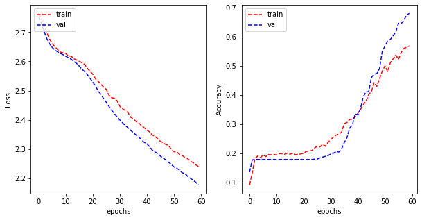

```python
history2 = model2C.fit_generator(train_generator2, validation_data = validation_generator2, epochs=60, verbose=1)
plot_learning_curve(history2.history['loss'], history2.history['val_loss'],
                    history2.history['categorical_accuracy'], history2.history['val_categorical_accuracy'],
                    metric_name='Accuracy')
```

```python
model2C.evaluate(test_generator2)
```

```
[2.1802652098037103, 0.6972973]
```

## It can be observed above, our accuracy is still very low and the loss is very high, this is not an acceptable outcome as it will not be able to classify the image properly

## Below i have decided to use something called early stopping to prevent overtraining and avoid the model from overfitting.

```python
from tensorflow.keras.callbacks import EarlyStopping
es = EarlyStopping(min_delta=0.001, monitor='val_loss', mode='min', verbose=1, patience=20, restore_best_weights=True,)
```

## I also change and added more layers to help get more accuracy. As I am adding more layers, this doesn't mean that this will increase the accuracy of the model as it might overfit the model. Therefore using Early stopping might stop the model from over fitting

```python
model2B = tf.keras.Sequential([

    tf.keras.layers.Conv2D(16, (3, 3), activation='relu', padding='same', input_shape=INPUT_DIM2),
    tf.keras.layers.Conv2D(16, (3, 3), activation='relu', padding='same'),
    tf.keras.layers.MaxPooling2D((2, 2)),

    tf.keras.layers.Conv2D(32, (3, 3), activation='relu', padding='same'),
    tf.keras.layers.Conv2D(32, (3, 3), activation='relu', padding='same'),
    tf.keras.layers.MaxPooling2D((2, 2)),


    tf.keras.layers.Conv2D(64, (3, 3), activation='relu', padding='same'),
    tf.keras.layers.Conv2D(64, (3, 3), activation='relu', padding='same'),
    tf.keras.layers.MaxPooling2D((2, 2)),


    tf.keras.layers.Conv2D(128, (3, 3), activation='relu', padding='same'),
    tf.keras.layers.Conv2D(128, (3, 3), activation='relu', padding='same'),
    tf.keras.layers.MaxPooling2D((2, 2)),

    tf.keras.layers.Flatten(),
    tf.keras.layers.Dense(128, activation='relu'),
    tf.keras.layers.Dense(OUTPUT_CLASSES2),
])
model2B.compile(optimizer='SGD',
              loss=tf.keras.losses.CategoricalCrossentropy(from_logits=True),
              metrics=['categorical_accuracy'])
```

[output not shown]

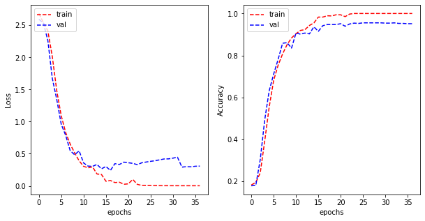

```python
history2EarlyStop = model2B.fit_generator(train_generator2, validation_data = validation_generator2, epochs=50, callbacks=[es], verbose=2)
plot_learning_curve(history2EarlyStop.history['loss'], history2EarlyStop.history['val_loss'],
                    history2EarlyStop.history['categorical_accuracy'], history2EarlyStop.history['val_categorical_accuracy'],
                    metric_name='Accuracy')
```

```python
model2B.evaluate(test_generator2)
```

```
[0.2701929984812034, 0.9216216]
```

```python
label_names = {'bicycle': 0,
 'continue': 1,
 'crossing': 2,
 'giveway': 3,
 'laneend': 4,
 'limitedtraffic': 5,
 'noentry': 6,
 'noparking': 7,
 'parking': 8,
 'rightofway': 9,
 'roundabout': 10,
 'speed': 11,
 'stop': 12,
 'trafficdirective': 13,
 'traveldirection': 14,
 'warning': 15}
```

## Now with our trained model, we have created a model that is able to classify sign types as show below.

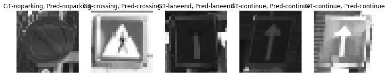

```python
d_inv2 = {v: k for k, v in label_names.items()}
plt.figure(figsize=(16,4))
batches = 0
for x,y in test_generator2:
        batches = batches + 1
        y_hat = model2B.predict(x, verbose=0)
        x = np.squeeze(x)
        if batches < 6:
            plt.subplot(1,6,batches)
            plt.imshow(x)
            plt.title("GT-{}, Pred-{}".format(d_inv2[np.argmax(y[0])], d_inv2[np.argmax(y_hat[0])] ))

        else:
            break

        plt.axis('off')
```

## We now completed, creating our models and it is time to choose which model is best suited to classify image sign and type

## We will now create some accuracy and f1 scores to compare the models easier

# Road Sign Shape Classification

## 1. Model A (Road Sign Shape Classification)

```python
y_hat_all = list()
y_all = list()
filenames = test_generator.filenames
N_images = len(filenames)
batches = 0
for x,y in test_generator:
        y_hat = modelA.predict(x, verbose=0)
        y_hat = np.argmax(y_hat, axis = 1)
        y = np.argmax(y, axis = 1)
        y_hat_all = y_hat_all + y_hat.tolist()
        y_all = y_all + y.tolist()
        batches += 1
        if batches >= N_images:
            break
print("modelA (sign shape) Accuracy score: ", accuracy_score(y_all, y_hat_all))
print("modelA (sign shape) F1 score: ", f1_score(y_all, y_hat_all, average='macro'))
print(confusion_matrix(y_all, y_hat_all))
```

```
modelA (sign shape) Accuracy score:  0.8864864864864865
modelA (sign shape) F1 score:  0.7088865419339129
[[ 59   0  14   0   3]
 [  0   0  12   0   0]
 [  1   0 329   7  15]
 [  0   0   5 123   7]
 [  1   0  14   5 145]]
```

## 2. Model B (Road Sign Shape Classification)

```python
y_hat_all = list()
y_all = list()
filenames = test_generator.filenames
N_images = len(filenames)
batches = 0
for x,y in test_generator:
        y_hat = modelB.predict(x, verbose=0)
        y_hat = np.argmax(y_hat, axis = 1)
        y = np.argmax(y, axis = 1)
        y_hat_all = y_hat_all + y_hat.tolist()
        y_all = y_all + y.tolist()
        batches += 1
        if batches >= N_images:
            break
print("modelB (sign shape) Accuracy score: ", accuracy_score(y_all, y_hat_all))
print("modelB (sign shape) F1 score: ", f1_score(y_all, y_hat_all, average='macro'))
print(confusion_matrix(y_all, y_hat_all))
```

```
modelB (sign shape) Accuracy score:  0.9702702702702702
modelB (sign shape) F1 score:  0.9423277463812489
[[ 54   1   5   0   4]
 [  2  15   1   0   0]
 [  1   0 334   2   2]
 [  0   0   1 136   0]
 [  1   0   2   0 179]]
```

# Road Sign Type Classification

## 1. Model C ( Road Sign Type Classification)

```python
y_hat_all = list()
y_all = list()
filenames = test_generator2.filenames
N_images = len(filenames)
batches = 0
for x,y in test_generator2:
        y_hat = model2C.predict(x, verbose=0)
        y_hat = np.argmax(y_hat, axis = 1)
        y = np.argmax(y, axis = 1)
        y_hat_all = y_hat_all + y_hat.tolist()
        y_all = y_all + y.tolist()
        batches += 1
        if batches >= N_images:
            break
print("model2C (sign type) Accuracy score): ", accuracy_score(y_all, y_hat_all))
print("model2C (sign type) F1 score: ", f1_score(y_all, y_hat_all, average='macro'))
print(confusion_matrix(y_all, y_hat_all))
```

```
model2C (sign type) Accuracy score):  0.6959459459459459
model2C (sign type) F1 score:  0.5160680516227267
[[ 54   0   0   0   0   0   1   2   0   0   0   0   0   0   0   7]
 [  1  44   0   1   0   0   0   0   0   0   0   0   0   0   0   1]
 [  0   0   0   0   0   0   0   0   0   0   0   0   0   0   0  23]
 [  3   0   0  42   0   0   0   0   0   0   0   0   0   0   0   2]
 [  4   0   0   0  12   0   0   0   0   0   0   0   0   0   0   1]
 [  0   0   0   2   0   0   0   0   0   1   0   0   0   0   0  15]
 [  3   0   0   1   0   0  69   0   0   2   0   0   0   0   0   0]
 [ 24   0   0   0   0   0   1  16   0   0   0   0   0   0   0   7]
 [  0   0   0   0   0   0   0   0  48   0   0   0   0   0   0   3]
 [  4   0   0   0   0   0   0   7   1  48   0   2   0   2   0   7]
 [  3   0   0   0   0   0   0   3   0   9   0   0   0   0   0   1]
 [  0   0   0   0   0   0   0   0   0   0   0  37   0   0   0  21]
 [  6   0   0   0   0   0   3   0   0   0   0   0   0   0   0   5]
 [  0   0   0   0   0   0   0   1   0   0   0  10   0  19   0   8]
 [  1   1   0   8   0   0   7   0   0   0   0   0   0   0   0   4]
 [  5   0   0   0   0   0   0   0   1   0   0   0   0   0   0 126]]
```

## 2. Model B ( Road Sign Type Classification)

```python
y_hat_all = list()
y_all = list()
filenames = test_generator2.filenames
N_images = len(filenames)
batches = 0
for x,y in test_generator2:
        y_hat = model2B.predict(x, verbose=0)
        y_hat = np.argmax(y_hat, axis = 1)
        y = np.argmax(y, axis = 1)
        y_hat_all = y_hat_all + y_hat.tolist()
        y_all = y_all + y.tolist()
        batches += 1
        if batches >= N_images:
            break
print("model2B (sign type) Accuracy score: ", accuracy_score(y_all, y_hat_all))
print("model2B (sign type) F1 score: ", f1_score(y_all, y_hat_all, average='macro'))
print(confusion_matrix(y_all, y_hat_all))
```

```
model2B (sign type) Accuracy score:  0.922972972972973
model2B (sign type) F1 score:  0.9062005699052981
[[ 63   0   0   0   1   0   0   1   0   0   0   0   0   0   0   0]
 [  1  45   0   0   0   0   0   0   0   0   0   0   0   0   0   0]
 [  0   0  22   0   0   0   0   0   0   0   0   0   0   0   0   1]
 [  0   0   0  46   0   1   0   0   1   0   0   0   0   0   0   1]
 [  1   0   0   0  16   0   0   0   0   0   0   0   0   0   0   0]
 [  0   0   0   0   0  17   0   0   0   0   0   0   0   1   0   0]
 [  3   0   0   0   0   0  68   0   0   1   2   0   0   0   2   0]
 [  2   0   0   0   0   4   0  42   0   0   0   0   0   0   0   0]
 [  0   0   0   0   0   0   0   0  53   0   0   0   0   0   0   0]
 [  0   0   0   0   0   3   0   1   0  53   5   0   0   1   0   3]
 [  0   0   0   0   0   0   0   1   0   1  14   0   0   0   0   0]
 [  0   0   0   0   0   3   0   0   0   1   0  53   0   1   0   0]
 [  0   0   0   0   0   0   0   0   0   0   0   0  13   0   0   1]
 [  0   0   0   0   0   1   0   0   0   0   0   4   0  33   0   0]
 [  1   1   0   1   0   0   1   0   0   0   0   0   0   0  17   0]
 [  1   0   0   0   0   0   0   0   0   1   2   0   0   0   0 128]]
```

## In conclusion, it can be concluded that for shape classifcation, although Model A produce a high accuracy, Model B is the better choice as it produce and accuracy of 97%

## Where as for Sign-Type classifcation, Model B (Sign-Type Classification) is the better choice than Model C as it produce only produce 69% accuracy , whereas Model B (Sign-Type Classification) produce 92% accuracy.

## Finally we will now save the models:

```python
modelB.save("Best_Model_B_Classify_Sign_Shape")
```

```python
model2B.save("Best_Model_B_Classify_Sign_Type")
```